# MTBS Assessment Types: Definitions and Spatial Bias

Do Initial and Extended assessments cluster systematically by geography, season, or fire size?

Published

August 11, 2026

```r
# =============================================================================
# SCRIPT OUTLINE
# 1. Setup — packages, paths, study parameters
# 2. Assessment type definitions (comparison table)
# 3. Load and filter MTBS data
# 4. Bias investigation plots
#    4.1 Fire counts by state — Extended only + Extended/Initial stacked (patchwork)
#    4.2 Fire count by ignition month — Initial vs Extended (stacked bar)
#    4.3 % forest cover within fire perimeters — histogram by state x assessment
#        type (reads cached CSV from scripts/r/05_prepare_forest_masks_west.R +
#        scripts/r/06_extract_pct_forest_within_fires.R; no raster work here)
#    4.4 % Extended vs. minimum forest-cover threshold — sweep 0-90% within
#        whichever state(s) are in the forest-cover cache (currently CA only),
#        to test whether the Initial/Extended split shifts once low-forest-cover
#        fires are excluded
# =============================================================================
```

## 1. Setup

```r
.install_if_missing <- function(pkgs) {
  missing <- pkgs[!pkgs %in% rownames(installed.packages())]
  if (length(missing) > 0) install.packages(missing, repos = "https://cloud.r-project.org", quiet = TRUE)
}
.install_if_missing(c("tigris", "ggspatial", "glue", "patchwork", "scales", "png"))

library(tidyverse)
library(sf)
library(tigris)
library(here)
library(scales)
library(glue)
library(patchwork)

options(tigris_use_cache = TRUE)
sf_use_s2(FALSE)

here::i_am("analysis/mtbs_assessment_comparison.qmd")

WESTERN_STATES <- c("AZ", "CA", "CO", "ID", "MT", "NV", "NM", "OR", "UT", "WA", "WY")
YEAR_MIN       <- 2000
YEAR_MAX       <- 2023
MTBS_PATH      <- here("data/raw/mtbs/mtbs_perimeter_data/mtbs_perims_DD.shp")

# Two-color palette: Initial (blue) vs Extended (red) — colorblind-safe
BINARY_COLORS <- c("Initial" = "#4393c3", "Extended" = "#d6604d")

dir.create(here("figures"), showWarnings = FALSE)
```

## 2. Assessment Type Definitions

MTBS assigns each fire an `asmnt_type` that records which post-fire Landsat image was used for burn severity mapping. The timing of that image affects the dNBR signal and the ecological interpretation of severity scores.

```r
bullets <- function(...) paste0("&bull; ", c(...), collapse = "<br>")

defn_tbl <- tribble(
  ~`Assessment Type`, ~`Post-fire image timing`,                          ~`Primary ecosystem`,       ~`Perimeter quality`,
  "Initial",          bullets("Shortly after containment",
                               "Ash/char cover, not regrowth"),            "Grasslands, shrublands",   bullets("Ash/char can mimic bare soil",
                                                                                                                 "Edges blur before growing season"),
  "Extended",         bullets("First growing season after fire",
                               "Vegetation response stabilized"),          "Forests",                  bullets("Green-up sharpens burn/unburn contrast",
                                                                                                                 "More refined low-severity edges")
)

knitr::kable(defn_tbl, align = "llll", escape = FALSE)
```

| Assessment Type | Post-fire image timing | Primary ecosystem | Perimeter quality |
| --- | --- | --- | --- |
| Initial | • Shortly after containment • Ash/char cover, not regrowth | Grasslands, shrublands | • Ash/char can mimic bare soil • Edges blur before growing season |
| Extended | • First growing season after fire • Vegetation response stabilized | Forests | • Green-up sharpens burn/unburn contrast • More refined low-severity edges |

Source: Kolden 2012.

## 3. Load and Filter MTBS Data

```r
mtbs_raw <- st_read(MTBS_PATH, quiet = TRUE)

stopifnot(all(c("event_id", "ig_date", "incid_type", "burnbndac",
                "asmnt_type", "pre_id", "post_id") %in% names(mtbs_raw)))

n_invalid <- sum(!st_is_valid(mtbs_raw))
if (n_invalid > 0) mtbs_raw <- st_make_valid(mtbs_raw)

cat("Records loaded:", nrow(mtbs_raw), "\n")
```

```
Records loaded: 30390
```

```r
# Get Western US state boundaries for spatial filter
western_states_sf <- states(cb = TRUE, progress_bar = FALSE) |>
  filter(STUSPS %in% WESTERN_STATES) |>
  st_transform(st_crs(mtbs_raw))

# --- Parse fields -------------------------------------------------------
mtbs_parsed <- mtbs_raw |>
  mutate(
    year  = as.integer(substr(ig_date, 1, 4)),
    month = as.integer(substr(ig_date, 6, 7)),
    # State extracted from event_id prefix (format: ST + lat + lon + date)
    state = substr(event_id, 1, 2),
    # Collapse 4 types to binary: any Extended → "Extended", else → "Initial"
    # SS variants (no pre-fire image) flagged separately for the lag plot
    asmnt_binary = case_when(
      asmnt_type %in% c("Extended", "Extended (SS)") ~ "Extended",
      TRUE                                            ~ "Initial"
    ),
    asmnt_ss = str_detect(asmnt_type, fixed("(SS)"))
  )

# Filter: wildfires only, Western US, 2000–2023
n0 <- nrow(mtbs_parsed)
mtbs_wf <- mtbs_parsed |> filter(incid_type == "Wildfire")
cat("After Wildfire filter:         ", nrow(mtbs_wf), "(removed", n0 - nrow(mtbs_wf), ")\n")
```

```
After Wildfire filter:          16446 (removed 13944 )
```

```r
mtbs_wf <- mtbs_wf |> filter(year >= YEAR_MIN, year <= YEAR_MAX)
cat("After year filter (2000–2023): ", nrow(mtbs_wf), "\n")
```

```
After year filter (2000–2023):  11463
```

```r
mtbs_joined <- st_join(mtbs_wf, western_states_sf["STUSPS"], join = st_intersects, left = FALSE)
cat("After Western US spatial filter (pre-dedup):", nrow(mtbs_joined), "\n")
```

```
After Western US spatial filter (pre-dedup): 6828
```

```r
# st_join() emits one row per polygon-boundary match, so a fire whose perimeter
# clips into a second state's boundary (e.g. an AZ fire nicking NM) gets counted
# twice — once per matching state. Replace the spatial match with MTBS's own
# state attribution (the event_id prefix, e.g. "AZ" in AZ3140510908020160321 —
# the same trick the CA-only extraction scripts use via startsWith(event_id, "CA"))
# and dedup to one row per fire. This also drops the rare case of a bordering
# non-Western state's fire poking into a Western state (event_id prefix outside
# WESTERN_STATES) — correctly excluded, since it isn't a Western-state fire.
mtbs_study <- mtbs_joined |>
  mutate(STUSPS = substr(event_id, 1, 2)) |>
  filter(STUSPS %in% WESTERN_STATES) |>
  distinct(event_id, .keep_all = TRUE)
cat("After state-attribution dedup:     ", nrow(mtbs_study), "\n")
```

```
After state-attribution dedup:      6633
```

```r
stopifnot("Duplicate event_ids after dedup" = !any(duplicated(mtbs_study$event_id)))
stopifnot(length(setdiff(WESTERN_STATES, unique(mtbs_study$STUSPS))) == 0)
cat("All 11 Western states present, no duplicate fires. ✓\n")
```

```
All 11 Western states present, no duplicate fires. ✓
```

```r
# Drop geometry for non-spatial summaries
mtbs_df <- st_drop_geometry(mtbs_study)

cat("\nAssessment type breakdown:\n")
```

```
Assessment type breakdown:
```

```r
print(count(mtbs_df, asmnt_type, sort = TRUE))
```

```
     asmnt_type    n
1       Initial 3737
2      Extended 2652
3  Initial (SS)  234
4 Extended (SS)   10
```

## 4. Bias Investigation

### 4.1 Fire Counts by State

Two views of the same data: the left plot shows Extended fires only; the right adds Initial fires as a stacked bar. Comparing them reveals both the absolute volume of Extended fires per state and how that volume relates to each state’s total fire activity.

```r
state_asmnt <- mtbs_df |>
  count(STUSPS, asmnt_binary) |>
  pivot_wider(names_from = asmnt_binary, values_from = n, values_fill = 0) |>
  mutate(
    total   = Initial + Extended,
    pct_ext = 100 * Extended / total
  )

overall_pct <- 100 * sum(state_asmnt$Extended) / sum(state_asmnt$total)
cat("Overall % Extended (Western US wildfires, 2000–2023):", round(overall_pct, 1), "%\n")
```

```
Overall % Extended (Western US wildfires, 2000–2023): 40.1 %
```

```r
print(arrange(state_asmnt, desc(Extended)))
```

```
# A tibble: 11 × 5
   STUSPS Extended Initial total pct_ext
   <chr>     <int>   <int> <int>   <dbl>
 1 CA          618     426  1044    59.2
 2 ID          400     557   957    41.8
 3 MT          354     332   686    51.6
 4 OR          237     376   613    38.7
 5 UT          178     253   431    41.3
 6 AZ          172     535   707    24.3
 7 WA          161     318   479    33.6
 8 WY          149     146   295    50.5
 9 CO          146     140   286    51.0
10 NV          141     453   594    23.7
11 NM          106     435   541    19.6
```

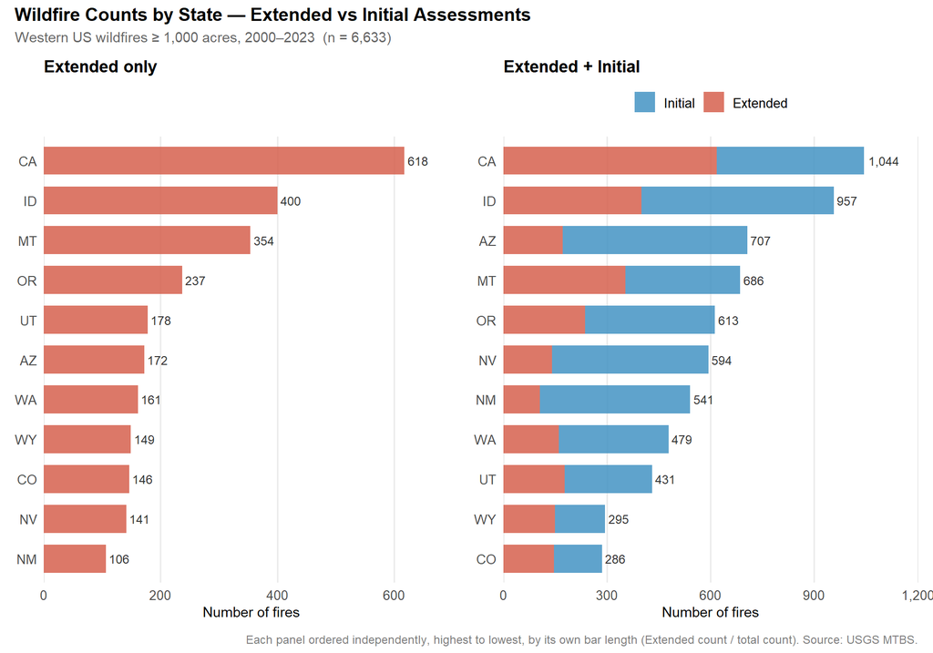

```r
# State order for Plot A: descending by Extended count (its own bar length)
state_order <- state_asmnt |> arrange(Extended) |> pull(STUSPS)

# State order for Plot B: descending by total count (its own bar length) —
# using the Extended-only order here would leave Plot B's stacked bars out
# of sequence whenever a state's Initial count reshuffles its total rank.
state_order_total <- state_asmnt |> arrange(total) |> pull(STUSPS)

state_long <- mtbs_df |>
  count(STUSPS, asmnt_binary) |>
  mutate(STUSPS = factor(STUSPS, levels = state_order))

state_long_total <- mtbs_df |>
  count(STUSPS, asmnt_binary) |>
  mutate(STUSPS = factor(STUSPS, levels = state_order_total))

# -- Plot A: Extended only ---------------------------------------------------
p_ext_only <- state_long |>
  filter(asmnt_binary == "Extended") |>
  ggplot(aes(x = n, y = STUSPS)) +
  geom_col(fill = BINARY_COLORS["Extended"], alpha = 0.85, width = 0.7) +
  geom_text(aes(label = comma(n)), hjust = -0.15, size = 3.3, color = "grey20") +
  scale_x_continuous(labels = comma, expand = expansion(mult = c(0, 0.15))) +
  labs(title = "Extended only", x = "Number of fires", y = NULL) +
  theme_minimal(base_size = 12) +
  theme(
    plot.title         = element_text(face = "bold", size = 13),
    panel.grid.minor   = element_blank(),
    panel.grid.major.y = element_blank(),
    axis.title.x       = element_text(size = 11),
    axis.text          = element_text(size = 10)
  )

# -- Plot B: Extended + Initial stacked --------------------------------------
p_stacked <- state_long_total |>
  mutate(asmnt_binary = factor(asmnt_binary, levels = c("Initial", "Extended"))) |>
  ggplot(aes(x = n, y = STUSPS, fill = asmnt_binary)) +
  geom_col(alpha = 0.85, width = 0.7) +
  geom_text(
    data = state_asmnt |> mutate(STUSPS = factor(STUSPS, levels = state_order_total)),
    aes(x = total, y = STUSPS, label = comma(total), fill = NULL),
    hjust = -0.15, size = 3.3, color = "grey20"
  ) +
  scale_fill_manual(values = BINARY_COLORS, name = NULL) +
  scale_x_continuous(labels = comma, expand = expansion(mult = c(0, 0.15))) +
  labs(title = "Extended + Initial", x = "Number of fires", y = NULL) +
  theme_minimal(base_size = 12) +
  theme(
    plot.title         = element_text(face = "bold", size = 13),
    panel.grid.minor   = element_blank(),
    panel.grid.major.y = element_blank(),
    axis.title.x       = element_text(size = 11),
    axis.text          = element_text(size = 10),
    legend.position    = "top",
    legend.text        = element_text(size = 10)
  )

p_state_counts <- (p_ext_only | p_stacked) +
  plot_annotation(
    title    = "Wildfire Counts by State — Extended vs Initial Assessments",
    subtitle = glue("Western US wildfires ≥ 1,000 acres, 2000–2023  (n = {comma(sum(state_asmnt$total))})"),
    caption  = "Each panel ordered independently, highest to lowest, by its own bar length (Extended count / total count). Source: USGS MTBS.",
    theme    = theme(
      plot.title    = element_text(face = "bold", size = 14),
      plot.subtitle = element_text(color = "grey40"),
      plot.caption  = element_text(color = "grey50", size = 9)
    )
  )

print(p_state_counts)
```

```r
stopifnot("All states have same Extended count — no variation" = sd(state_asmnt$Extended) > 0)

ggsave(here("figures/asmnt_counts_by_state.png"),
       plot = p_state_counts, width = 14, height = 7, dpi = 300, bg = "white")
img_dims <- dim(png::readPNG(here("figures/asmnt_counts_by_state.png")))
cat("Plot 4.1 saved — dimensions (px):", img_dims[2], "x", img_dims[1], "\n")
```

```
Plot 4.1 saved — dimensions (px): 4200 x 2100
```

### 4.2 Fire Count by Ignition Month

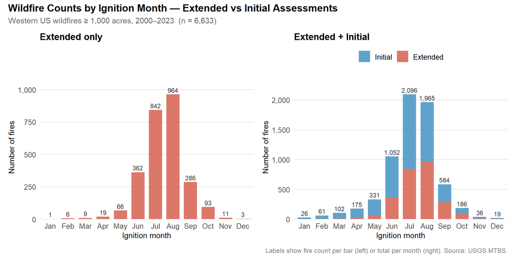

```r
month_count <- mtbs_df |>
  filter(!is.na(month)) |>
  count(month, asmnt_binary) |>
  mutate(mon_lbl = factor(month.abb[month], levels = month.abb))

month_totals <- month_count |>
  group_by(mon_lbl) |>
  summarise(total = sum(n), .groups = "drop")

theme_month <- theme_minimal(base_size = 12) +
  theme(
    plot.title         = element_text(face = "bold", size = 13),
    panel.grid.minor   = element_blank(),
    panel.grid.major.x = element_blank(),
    axis.title         = element_text(size = 11),
    axis.text          = element_text(size = 10)
  )

# -- Plot A: Extended only ---------------------------------------------------
p_month_ext <- month_count |>
  filter(asmnt_binary == "Extended") |>
  ggplot(aes(x = mon_lbl, y = n)) +
  geom_col(fill = BINARY_COLORS["Extended"], alpha = 0.85, width = 0.75) +
  geom_text(aes(label = comma(n)), vjust = -0.4, size = 3.2, color = "grey20") +
  scale_y_continuous(labels = comma, expand = expansion(mult = c(0, 0.15))) +
  labs(title = "Extended only", x = "Ignition month", y = "Number of fires") +
  theme_month

# -- Plot B: Extended + Initial stacked --------------------------------------
p_month_stacked <- month_count |>
  mutate(asmnt_binary = factor(asmnt_binary, levels = c("Initial", "Extended"))) |>
  ggplot(aes(x = mon_lbl, y = n, fill = asmnt_binary)) +
  geom_col(alpha = 0.85, width = 0.75) +
  geom_text(
    data = month_totals,
    aes(x = mon_lbl, y = total, label = comma(total), fill = NULL),
    vjust = -0.4, size = 3.2, color = "grey20"
  ) +
  scale_fill_manual(values = BINARY_COLORS, name = NULL) +
  scale_y_continuous(labels = comma, expand = expansion(mult = c(0, 0.15))) +
  labs(title = "Extended + Initial", x = "Ignition month", y = "Number of fires") +
  theme_month +
  theme(legend.position = "top", legend.text = element_text(size = 10))

p_month_counts <- (p_month_ext | p_month_stacked) +
  plot_annotation(
    title    = "Wildfire Counts by Ignition Month — Extended vs Initial Assessments",
    subtitle = glue("Western US wildfires ≥ 1,000 acres, 2000–2023  (n = {comma(sum(month_totals$total))})"),
    caption  = "Labels show fire count per bar (left) or total per month (right). Source: USGS MTBS.",
    theme    = theme(
      plot.title    = element_text(face = "bold", size = 14),
      plot.subtitle = element_text(color = "grey40"),
      plot.caption  = element_text(color = "grey50", size = 9)
    )
  )

print(p_month_counts)
```

```r
ggsave(here("figures/asmnt_counts_by_month.png"),
       plot = p_month_counts, width = 14, height = 6, dpi = 300, bg = "white")
img_dims <- dim(png::readPNG(here("figures/asmnt_counts_by_month.png")))
cat("Plot 4.2 saved — dimensions (px):", img_dims[2], "x", img_dims[1], "\n")
```

```
Plot 4.2 saved — dimensions (px): 4200 x 1800
```

### 4.3 Forest Cover Within Fire Perimeters

Extended assessments wait for the first growing season and are documented (§2) to suit forest ecosystems better than Initial assessments. This section checks that directly: for each fire, what % of its perimeter is forest (NLCD 2004, classes 41/42/43 — Deciduous/Evergreen/Mixed), and does that distribution differ between Initial and Extended fires, by state?

Heavy raster work (NLCD download + per-polygon crop/mask) runs outside Quarto — see `scripts/r/05_prepare_forest_masks_west.R` and `scripts/r/06_extract_pct_forest_within_fires.R`. This section only reads their cached CSV output.

```r
PCT_FOREST_CSV <- here("data", "processed", "forest_mask", "pct_forest_by_fire_west.csv")
PCT_FOREST_AVAILABLE <- file.exists(PCT_FOREST_CSV)

if (!PCT_FOREST_AVAILABLE) {
  message("Forest-cover cache not found (", basename(PCT_FOREST_CSV), ").\n",
          "Run, from the project root:\n",
          "  Rscript scripts/r/05_prepare_forest_masks_west.R\n",
          "  Rscript scripts/r/06_extract_pct_forest_within_fires.R\n",
          "then re-render this document. Skipping §4.3.")
} else {
  pct_forest_raw <- readr::read_csv(PCT_FOREST_CSV, show_col_types = FALSE)

  cat("States in forest-cover cache:", paste(sort(unique(pct_forest_raw$STUSPS)), collapse = ", "), "\n")

  # Sanity: 0 masked pixels signals a CRS/off-grid crop-mask mismatch (the same
  # bug class documented elsewhere in this repo for eMapR extraction), not a
  # genuinely 0%-forest fire.
  n_zero_px <- sum(pct_forest_raw$n_pixels == 0, na.rm = TRUE)
  if (n_zero_px > 0) {
    message(n_zero_px, " fire(s) have 0 masked pixels — check CRS/grid alignment before trusting pct_forest for these.")
  }

  # Restrict to fires also present in this doc's own study cohort (mtbs_df),
  # so §4.3 always reflects exactly the same population as §4.1/4.2.
  pct_forest_df <- pct_forest_raw |>
    filter(event_id %in% mtbs_df$event_id, n_pixels > 0) |>
    mutate(asmnt_binary = factor(asmnt_binary, levels = c("Initial", "Extended")))

  stopifnot("Duplicate event_id in forest-cover cache" = !any(duplicated(pct_forest_df$event_id)))

  cat("Fires with forest-cover data:", nrow(pct_forest_df), "of", nrow(mtbs_df),
      glue(" ({round(100 * nrow(pct_forest_df) / nrow(mtbs_df), 1)}%)"), "\n")
}
```

```
States in forest-cover cache: CA
Fires with forest-cover data: 1044 of 6633  (15.7%)
```

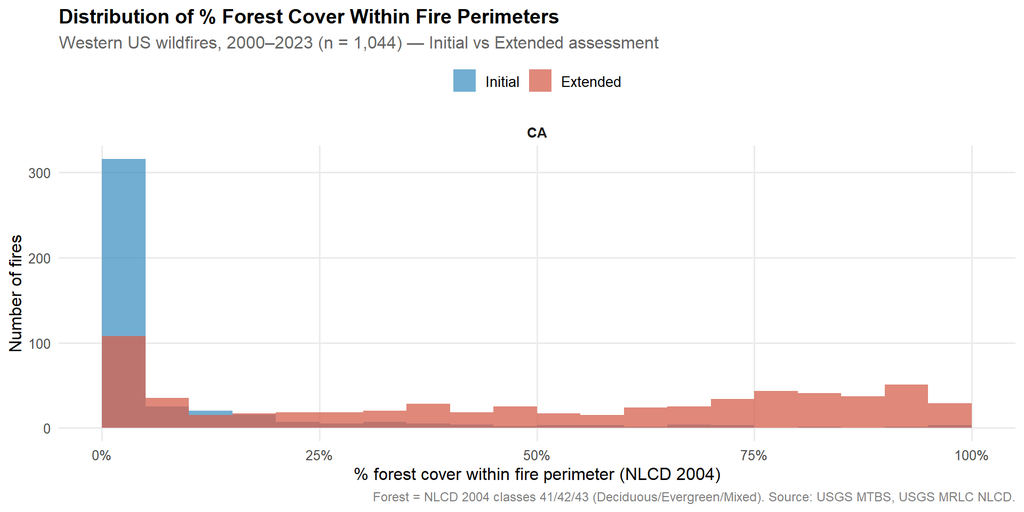

```
Plot 4.3 saved — dimensions (px): 4200 x 1500
```

```r
if (PCT_FOREST_AVAILABLE && nrow(pct_forest_df) > 0) {
  p_pct_forest <- ggplot(pct_forest_df, aes(x = pct_forest, fill = asmnt_binary)) +
    geom_histogram(binwidth = 5, boundary = 0, alpha = 0.75, position = "identity") +
    scale_fill_manual(values = BINARY_COLORS, name = NULL) +
    scale_x_continuous(labels = function(x) paste0(x, "%"),
                        breaks = seq(0, 100, 25)) +
    scale_y_continuous(labels = comma) +
    facet_wrap(~STUSPS, scales = "free_y") +
    labs(
      title    = "Distribution of % Forest Cover Within Fire Perimeters",
      subtitle = glue("Western US wildfires, 2000–2023 (n = {comma(nrow(pct_forest_df))}) — ",
                       "Initial vs Extended assessment"),
      x        = "% forest cover within fire perimeter (NLCD 2004)",
      y        = "Number of fires",
      caption  = "Forest = NLCD 2004 classes 41/42/43 (Deciduous/Evergreen/Mixed). Source: USGS MTBS, USGS MRLC NLCD."
    ) +
    theme_minimal(base_size = 12) +
    theme(
      plot.title       = element_text(face = "bold", size = 14),
      plot.subtitle    = element_text(color = "grey40"),
      plot.caption     = element_text(color = "grey50", size = 9),
      panel.grid.minor = element_blank(),
      legend.position  = "top",
      legend.text      = element_text(size = 10),
      strip.text       = element_text(face = "bold")
    )

  print(p_pct_forest)

  ggsave(here("figures/pct_forest_hist_by_state.png"),
         plot = p_pct_forest, width = 14, height = 5, dpi = 300, bg = "white")
  img_dims <- dim(png::readPNG(here("figures/pct_forest_hist_by_state.png")))
  cat("Plot 4.3 saved — dimensions (px):", img_dims[2], "x", img_dims[1], "\n")
} else {
  cat("Skipping plot — forest-cover cache not available.\n")
}
```

```r
if (PCT_FOREST_AVAILABLE && nrow(pct_forest_df) > 0) {
  pct_forest_tbl <- pct_forest_df |>
    group_by(STUSPS, asmnt_binary) |>
    summarise(
      n_fires            = n(),
      median_pct_forest  = median(pct_forest, na.rm = TRUE),
      mean_pct_forest    = mean(pct_forest, na.rm = TRUE),
      .groups = "drop"
    ) |>
    arrange(STUSPS, asmnt_binary)

  knitr::kable(
    pct_forest_tbl, digits = 1,
    col.names = c("State", "Assessment", "n fires", "Median % forest", "Mean % forest"),
    caption = "Forest cover within fire perimeters by state and assessment type (NLCD 2004)."
  )
} else {
  cat("Skipping summary table — forest-cover cache not available.\n")
}
```

Forest cover within fire perimeters by state and assessment type (NLCD 2004).

| State | Assessment | n fires | Median % forest | Mean % forest |
| --- | --- | --- | --- | --- |
| CA | Initial | 426 | 0.4 | 7.6 |
| CA | Extended | 618 | 52.4 | 49.1 |

### 4.4 % Extended vs. Minimum Forest-Cover Threshold

**Warning**

**This section currently covers only the state(s) present in the forest-cover cache, not all 11 Western states**

`scripts/r/06_extract_pct_forest_within_fires.R` defaults to `STATES_TO_RUN <- c("CA")` and has not yet been re-run for the other 10 states. So unlike §4.1/4.2 (all 11 states), §4.3 and this section reflect only the state(s) printed below under “States in forest-cover cache.” The baseline reference line in the plot below is therefore the %-Extended for *that same state subset* at threshold 0 (not §4.1’s all-11-state baseline of 40.1%) — otherwise the comparison would conflate “restricting to CA” with “restricting to forest.” Re-run `05_prepare_forest_masks_west.R` + `06_extract_pct_forest_within_fires.R` with the other states added to `STATES_TO_RUN` before generalizing this trend beyond CA.

```r
if (PCT_FOREST_AVAILABLE && nrow(pct_forest_df) > 0) {
  THRESHOLDS <- seq(0, 90, by = 5)

  sweep_tbl <- purrr::map_dfr(THRESHOLDS, function(th) {
    subset  <- pct_forest_df |> filter(pct_forest >= th)
    n_tot   <- nrow(subset)
    n_ext   <- sum(subset$asmnt_binary == "Extended")
    tibble(
      threshold    = th,
      n_fires      = n_tot,
      n_extended   = n_ext,
      pct_extended = if (n_tot > 0) 100 * n_ext / n_tot else NA_real_
    )
  })

  # Baseline for reference: % Extended at threshold 0 WITHIN the same state
  # subset the sweep uses (pct_forest_df), not §4.1's all-11-state overall_pct
  # — comparing to the all-state baseline would conflate "restricted to the
  # cached state(s)" with "restricted by forest cover" (see callout above).
  cache_states      <- sort(unique(pct_forest_df$STUSPS))
  baseline_pct_ext  <- sweep_tbl$pct_extended[sweep_tbl$threshold == 0]

  stopifnot(
    "n_fires must be non-increasing as threshold rises" =
      all(diff(sweep_tbl$n_fires) <= 0),
    "pct_extended must stay within [0, 100]" =
      all(sweep_tbl$pct_extended[!is.na(sweep_tbl$pct_extended)] >= 0 &
          sweep_tbl$pct_extended[!is.na(sweep_tbl$pct_extended)] <= 100)
  )

  cat("States in forest-cover cache used by this sweep:", paste(cache_states, collapse = ", "), "\n")

  cat("Threshold sweep (0-90% by 5):\n")
  print(sweep_tbl, n = Inf)
} else {
  cat("Skipping threshold sweep — forest-cover cache not available.\n")
}
```

```
States in forest-cover cache used by this sweep: CA
Threshold sweep (0-90% by 5):
# A tibble: 19 × 4
   threshold n_fires n_extended pct_extended
       <dbl>   <int>      <int>        <dbl>
 1         0    1044        618         59.2
 2         5     620        510         82.3
 3        10     560        475         84.8
 4        15     525        460         87.6
 5        20     492        443         90.0
 6        25     467        425         91.0
 7        30     444        407         91.7
 8        35     417        387         92.8
 9        40     384        359         93.5
10        45     362        341         94.2
11        50     335        316         94.3
12        55     315        299         94.9
13        60     297        284         95.6
14        65     272        260         95.6
15        70     243        235         96.7
16        75     206        201         97.6
17        80     163        158         96.9
18        85     121        117         96.7
19        90      84         80         95.2
```

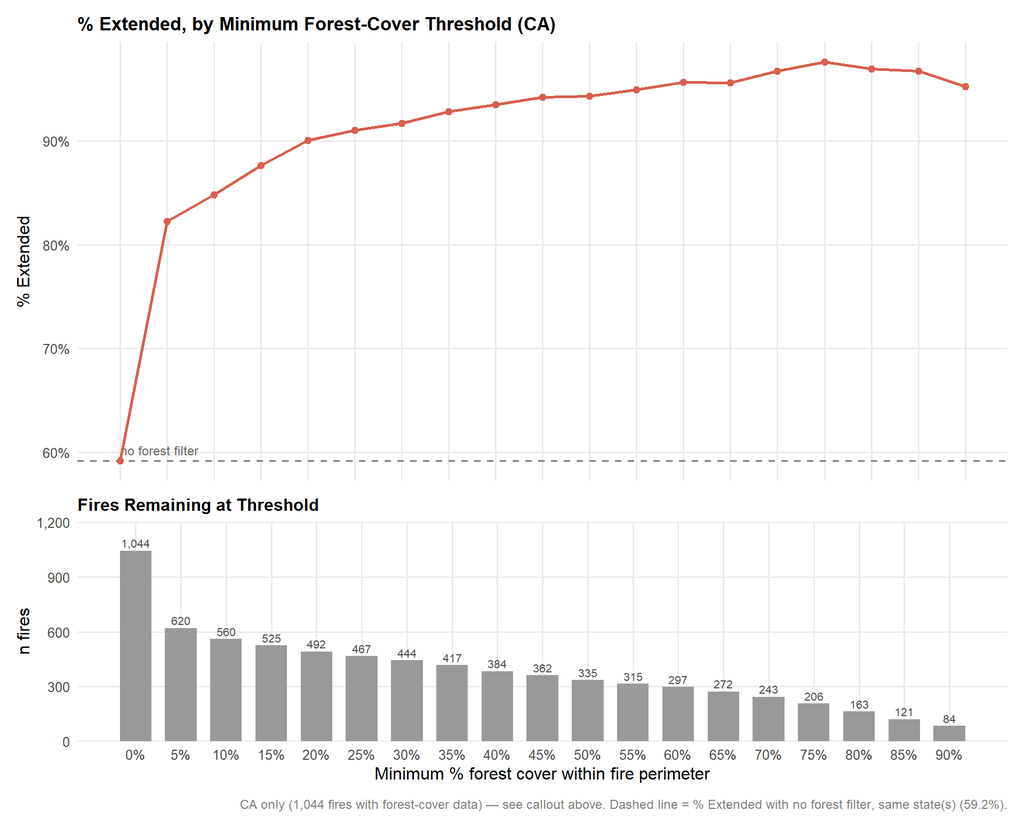

```
Plot 4.4 saved — dimensions (px): 3000 x 2400
```

```r
if (PCT_FOREST_AVAILABLE && nrow(pct_forest_df) > 0) {
  p_sweep_pct <- ggplot(sweep_tbl, aes(x = threshold, y = pct_extended)) +
    geom_hline(yintercept = baseline_pct_ext, linetype = "dashed", color = "grey50") +
    annotate("text", x = 0, y = baseline_pct_ext, label = "no forest filter",
             hjust = 0, vjust = -0.6, size = 3.2, color = "grey40") +
    geom_line(color = BINARY_COLORS["Extended"], linewidth = 0.9) +
    geom_point(color = BINARY_COLORS["Extended"], size = 2) +
    scale_x_continuous(labels = function(x) paste0(x, "%"), breaks = THRESHOLDS) +
    scale_y_continuous(labels = function(x) paste0(x, "%")) +
    labs(
      title = glue("% Extended, by Minimum Forest-Cover Threshold ({paste(cache_states, collapse = ', ')})"),
      x     = NULL,
      y     = "% Extended"
    ) +
    theme_minimal(base_size = 12) +
    theme(
      plot.title       = element_text(face = "bold", size = 13),
      panel.grid.minor = element_blank(),
      axis.text.x      = element_blank()
    )

  p_sweep_n <- ggplot(sweep_tbl, aes(x = threshold, y = n_fires)) +
    geom_col(fill = "grey60", width = 3.5) +
    geom_text(aes(label = comma(n_fires)), vjust = -0.4, size = 2.8, color = "grey30") +
    scale_x_continuous(labels = function(x) paste0(x, "%"), breaks = THRESHOLDS) +
    scale_y_continuous(labels = comma, expand = expansion(mult = c(0, 0.15))) +
    labs(
      title = "Fires Remaining at Threshold",
      x     = "Minimum % forest cover within fire perimeter",
      y     = "n fires"
    ) +
    theme_minimal(base_size = 12) +
    theme(
      plot.title       = element_text(face = "bold", size = 12),
      panel.grid.minor = element_blank()
    )

  p_sweep <- p_sweep_pct / p_sweep_n +
    plot_layout(heights = c(2, 1)) +
    plot_annotation(
      caption = glue("{paste(cache_states, collapse = ', ')} only ({comma(nrow(pct_forest_df))} fires with forest-cover data) — ",
                      "see callout above. Dashed line = % Extended with no forest filter, same state(s) ({round(baseline_pct_ext, 1)}%)."),
      theme = theme(plot.caption = element_text(color = "grey50", size = 9))
    )

  print(p_sweep)

  ggsave(here("figures/pct_extended_by_forest_threshold.png"),
         plot = p_sweep, width = 10, height = 8, dpi = 300, bg = "white")
  img_dims <- dim(png::readPNG(here("figures/pct_extended_by_forest_threshold.png")))
  cat("Plot 4.4 saved — dimensions (px):", img_dims[2], "x", img_dims[1], "\n")
} else {
  cat("Skipping plot — forest-cover cache not available.\n")
}
```

## Summary

```r
month_initial_peak <- month_count |>
  filter(asmnt_binary == "Initial") |>
  slice_max(n, n = 1)

month_pct_ext <- month_count |>
  pivot_wider(names_from = asmnt_binary, values_from = n, values_fill = 0) |>
  mutate(pct_ext = 100 * Extended / (Initial + Extended),
         mon_lbl = factor(month.abb[month], levels = month.abb)) |>
  slice_max(pct_ext, n = 1)

summary_tbl <- tribble(
  ~Metric,                                   ~Value,
  "Total Western US wildfires (2000–2023)",   comma(sum(state_asmnt$total)),
  "Extended assessments — count (%)",         glue("{comma(sum(state_asmnt$Extended))} ({round(overall_pct, 1)}%)"),
  "Highest % Extended state",                 with(state_asmnt, glue("{STUSPS[which.max(pct_ext)]} ({round(max(pct_ext), 1)}%)")),
  "Lowest % Extended state",                  with(state_asmnt, glue("{STUSPS[which.min(pct_ext)]} ({round(min(pct_ext), 1)}%)")),
  "Peak month for % Extended",                glue("{month_pct_ext$mon_lbl} ({round(month_pct_ext$pct_ext, 1)}%)"),
  "Peak month for Initial fire count",        glue("{month_initial_peak$mon_lbl} ({comma(month_initial_peak$n)} fires)")
)

knitr::kable(summary_tbl, col.names = c("Metric", "Value"), align = "lr")
```

| Metric | Value |
| --- | --- |
| Total Western US wildfires (2000–2023) | 6,633 |
| Extended assessments — count (%) | 2,662 (40.1%) |
| Highest % Extended state | CA (59.2%) |
| Lowest % Extended state | NM (19.6%) |
| Peak month for % Extended | Oct (50%) |
| Peak month for Initial fire count | Jul (1,254 fires) |

**Important**

Recommendation for this study (wildfire impact on biomass):

Include both assessment types.

The assessment type differs in what ecological changes are visible at the time of MTBS mapping (Key 2006), but perimeters represent the same burned area. Our outcome variable (annual biomass) is measured consistently for all fires using the same CTrees methodology, independent of MTBS assessment type.